# Food Choices and Preference of College Students

Charlene

2023-08-09

## Loading readr package

Dataset used for this project was imported using readr package. To do so, the tidyverse package which contains readr package was installed and loaded.

## Data cleaning

#### Preview dataset

Packages required in this step: Here, Skimr, Janitor, dply.

```r
head(food_survey_respond_df)
```

```
## # A tibble: 6 × 61
##   GPA   Gender breakfast calories_chicken calories_day calories_scone coffee
##   <chr>  <dbl>     <dbl>            <dbl>        <dbl>          <dbl>  <dbl>
## 1 2.4        2         1              430          NaN            315      1
## 2 3.654      1         1              610            3            420      2
## 3 3.3        1         1              720            4            420      2
## 4 3.2        1         1              430            3            420      2
## 5 3.5        1         1              720            2            420      2
## 6 2.25       1         1              610            3            980      2
## # ℹ 54 more variables: comfort_food <chr>, comfort_food_reasons <chr>,
## #   comfort_food_reasons_coded...10 <dbl>, cook <dbl>,
## #   comfort_food_reasons_coded...12 <dbl>, cuisine <dbl>, diet_current <chr>,
## #   diet_current_coded <dbl>, drink <dbl>, eating_changes <chr>,
## #   eating_changes_coded <dbl>, eating_changes_coded1 <dbl>, eating_out <dbl>,
## #   employment <dbl>, ethnic_food <dbl>, exercise <dbl>,
## #   father_education <dbl>, father_profession <chr>, fav_cuisine <chr>, …
```

```r
dplyr::glimpse(food_survey_respond_df)
```

```
## Rows: 125
## Columns: 61
## $ GPA                             <chr> "2.4", "3.654", "3.3", "3.2", "3.5", "…
## $ Gender                          <dbl> 2, 1, 1, 1, 1, 1, 2, 1, 1, 1, 1, 1, 2,…
## $ breakfast                       <dbl> 1, 1, 1, 1, 1, 1, 1, 1, 1, 1, 1, 1, 1,…
## $ calories_chicken                <dbl> 430, 610, 720, 430, 720, 610, 610, 720…
## $ calories_day                    <dbl> NaN, 3, 4, 3, 2, 3, 3, 3, NaN, 3, 3, 4…
## $ calories_scone                  <dbl> 315, 420, 420, 420, 420, 980, 420, 420…
## $ coffee                          <dbl> 1, 2, 2, 2, 2, 2, 2, 1, 1, 2, 2, 2, 2,…
## $ comfort_food                    <chr> "none", "chocolate, chips, ice cream",…
## $ comfort_food_reasons            <chr> "we dont have comfort", "Stress, bored…
## $ comfort_food_reasons_coded...10 <dbl> 9, 1, 1, 2, 1, 4, 1, 1, 2, 1, 2, 3, 3,…
## $ cook                            <dbl> 2, 3, 1, 2, 1, 3, 2, 3, 3, 3, 1, 3, 5,…
## $ comfort_food_reasons_coded...12 <dbl> 9, 1, 1, 2, 1, 4, 1, 1, 2, 1, 2, 3, 3,…
## $ cuisine                         <dbl> NaN, 1, 3, 2, 2, NaN, 1, 1, 1, 1, 1, 1…
```

[output cut: 48 more lines]

```r
colnames(food_survey_respond_df)
```

```
##  [1] "GPA"                             "Gender"
##  [3] "breakfast"                       "calories_chicken"
##  [5] "calories_day"                    "calories_scone"
##  [7] "coffee"                          "comfort_food"
##  [9] "comfort_food_reasons"            "comfort_food_reasons_coded...10"
## [11] "cook"                            "comfort_food_reasons_coded...12"
## [13] "cuisine"                         "diet_current"
## [15] "diet_current_coded"              "drink"
## [17] "eating_changes"                  "eating_changes_coded"
## [19] "eating_changes_coded1"           "eating_out"
## [21] "employment"                      "ethnic_food"
## [23] "exercise"                        "father_education"
## [25] "father_profession"               "fav_cuisine"
## [27] "fav_cuisine_coded"               "fav_food"
## [29] "food_childhood"                  "fries"
```

[output cut: 16 more lines]

## Data Transformation

In this part of the analysis, 3 new dataframes will be created with variables of interest that were required to answer the following questions:

- Question 1: Does exercising regularly affects weight of an individual?
- Question 2: Does factors such as: Employment, Income, and Living on or off campus affect the frequency of eating out for college students?
- Question 3: Does students who exercise regularly more likely to make better food choices?

#### Question 1: Creating new dataframe with variables of interest

In the preview of the food_survey_respond_df, there are 61 variables in this dataset. Not all the variables will be needed in our analysis, therefore, only the variables of interest will be selected and stored in a new dataframe for easy access later.

```r
library(tidyr)
library(dplyr)
weight_df<- food_survey_respond_df %>%
  select("Gender","exercise","weight") %>%
  drop_na()

weight_df %>%
  count(weight) # to identify which responds needs cleaning / removing
```

```
## # A tibble: 42 × 2
##    weight     n
##    <chr>  <int>
##  1 110        1
##  2 112        1
##  3 115        1
##  4 116        1
##  5 118        1
##  6 120        3
##  7 123        1
##  8 125        4
##  9 128        2
## 10 129        2
## # ℹ 32 more rows
```

```r
weight_df %>%
  count(Gender) # should have 1 & 2 only. 1= Female, 2 = Male
```

```
## # A tibble: 2 × 2
##   Gender     n
##    <dbl> <int>
## 1      1    65
## 2      2    47
```

```r
weight_df %>%
  count(exercise)
```

```
## # A tibble: 3 × 2
##   exercise     n
##      <dbl> <int>
## 1        1    57
## 2        2    44
## 3        3    11
```

There are 4 rows in weight that needs cleaning before we can start analysis.

```r
library(stringr)
weight_df$weight <- str_replace_all(weight_df$weight, "^144 lbs$", "144")
weight_df$weight <- str_replace_all(weight_df$weight, "^Not sure, 240$", "240")

#Removing Row 3 & row 66
weight_df<- weight_df[-c(3,66),]

#Double checking the data within weight to make sure we have cleaned up properly
weight_df %>%
  count(weight)
```

```
## # A tibble: 40 × 2
##    weight     n
##    <chr>  <int>
##  1 110        1
##  2 112        1
##  3 115        1
##  4 116        1
##  5 118        1
##  6 120        3
##  7 123        1
##  8 125        4
##  9 128        2
## 10 129        2
## # ℹ 30 more rows
```

#### Question 1: Replace Integer respond for Gender with String

```r
weight_df <- weight_df %>%
  mutate(Gender_new=case_match(
           Gender,
           1~'Female',
           2~'Male'
         )
         )

weight_df %>%
  count(Gender, Gender_new)
```

```
## # A tibble: 2 × 3
##   Gender Gender_new     n
##    <dbl> <chr>      <int>
## 1      1 Female        64
## 2      2 Male          46
```

#### Question 1: Replace Integer respond for exercise with String

```r
weight_df <- weight_df %>%
  mutate(exercise_new=case_match(
           exercise,
           1~"Everyday",
           2~"2-3 times a week",
           3~"Once a week",
           4~"Sometimes",
           5~"Never"
         )
         )

weight_df %>%
  count(exercise_new, exercise)
```

```
## # A tibble: 3 × 3
##   exercise_new     exercise     n
##   <chr>               <dbl> <int>
## 1 2-3 times a week        2    42
## 2 Everyday                1    57
## 3 Once a week             3    11
```

#### Question 1: Replace Integer respond for weight with String

```r
weight_df <- weight_df %>%
   mutate(weight_range = case_when(
     weight <130 ~'110 - 129 lbs',
     weight <160 ~ '130 - 159 lbs',
     weight < 190 ~'160 - 189 lbs',
     TRUE ~ '>=190 lbs'
     )
     )
weight_df %>%
  count(weight_range, weight)
```

```
## # A tibble: 40 × 3
##    weight_range  weight     n
##    <chr>         <chr>  <int>
##  1 110 - 129 lbs 110        1
##  2 110 - 129 lbs 112        1
##  3 110 - 129 lbs 115        1
##  4 110 - 129 lbs 116        1
##  5 110 - 129 lbs 118        1
##  6 110 - 129 lbs 120        3
##  7 110 - 129 lbs 123        1
##  8 110 - 129 lbs 125        4
##  9 110 - 129 lbs 128        2
## 10 110 - 129 lbs 129        2
## # ℹ 30 more rows
```

#### Question 2: Creating new dataframe with variables of interest

```r
frequency_df <- food_survey_respond_df %>%
  select ("eating_out","employment","income","on_off_campus") %>%
  drop_na()

glimpse(frequency_df)
```

```
## Rows: 115
## Columns: 4
## $ eating_out    <dbl> 3, 2, 2, 2, 2, 1, 2, 2, 5, 3, 2, 1, 1, 4, 2, 4, 1, 2, 3,…
## $ employment    <dbl> 3, 2, 3, 3, 2, 3, 3, 2, 2, 3, 1, 2, 3, 2, 3, 3, 2, 3, 2,…
## $ income        <dbl> 5, 4, 6, 6, 6, 1, 4, 5, 5, 4, 3, 5, 5, 5, 5, 4, 1, 6, 5,…
## $ on_off_campus <dbl> 1, 1, 2, 1, 1, 1, 2, 1, 1, 1, 3, 1, 1, 2, 2, 1, 1, 1, 1,…
```

#### Question 2: Replace Integer respond for eating_out with String

```r
frequency_df <- frequency_df %>%
  mutate(eating_out_new= case_match(
    eating_out,
    1 ~ "Never",
    2 ~ "1-2 times",
    3 ~ "2-3 times",
    4 ~ "3-4 times",
    5 ~ "Everyday"
  )
  )
frequency_df %>%
  count(eating_out_new, eating_out) # checking if above code has been run correctly
```

```
## # A tibble: 5 × 3
##   eating_out_new eating_out     n
##   <chr>               <dbl> <int>
## 1 1-2 times               2    56
## 2 2-3 times               3    21
## 3 3-4 times               4    13
## 4 Everyday                5    10
## 5 Never                   1    15
```

#### Question 2: Replace Integer respond for employment with String

```r
frequency_df <- frequency_df %>%
  mutate(employment_new = case_match(
    employment,
    1 ~ "Full time",
    2 ~ "Part time",
    3 ~ "Unemployed"
  )
  )
frequency_df %>%
  count(employment_new, employment)
```

```
## # A tibble: 3 × 3
##   employment_new employment     n
##   <chr>               <dbl> <int>
## 1 Full time               1     2
## 2 Part time               2    60
## 3 Unemployed              3    53
```

#### Question 2: Replace Integer respond for income with String

```r
frequency_df <- frequency_df %>%
  mutate(income_range = case_match(
    income,
    1 ~ "less than $15K",
    2 ~ ">$15K - $30K",
    3 ~ ">$30K - $50K",
    4 ~ ">$50K - $70K",
    5 ~ ">$70K - $100K",
    6 ~ "more than $100K"
  )
  )

frequency_df %>%
  count(income, income_range)
```

```
## # A tibble: 6 × 3
##   income income_range        n
##    <dbl> <chr>           <int>
## 1      1 less than $15K      4
## 2      2 >$15K - $30K        7
## 3      3 >$30K - $50K       14
## 4      4 >$50K - $70K       19
## 5      5 >$70K - $100K      32
## 6      6 more than $100K    39
```

#### Question 2: Replace Integer respond for living on and off campus with String

```r
frequency_df <- frequency_df %>%
  mutate(living_on_off_campus = case_when(
    on_off_campus == 1 ~ "On campus",
    TRUE ~ "Off campus"
  )
  )

frequency_df %>%
  count(on_off_campus, living_on_off_campus)
```

```
## # A tibble: 4 × 3
##   on_off_campus living_on_off_campus     n
##           <dbl> <chr>                <int>
## 1             1 On campus               90
## 2             2 Off campus              15
## 3             3 Off campus               8
## 4             4 Off campus               2
```

#### Question 3: Creating new dataframe with variables of interest

```r
exercise_df <- food_survey_respond_df %>%
  select ("exercise","nutritional_check","veggies_day","fruit_day") %>%
  drop_na()

glimpse(exercise_df)
```

```
## Rows: 112
## Columns: 4
## $ exercise          <dbl> 1, 1, 2, 3, 1, 2, 1, 2, 1, 1, 1, 3, 2, 2, 1, 2, 1, 3…
## $ nutritional_check <dbl> 5, 4, 4, 2, 3, 1, 4, 4, 5, 2, 5, 2, 2, 2, 1, 4, 4, 2…
## $ veggies_day       <dbl> 5, 4, 5, 3, 4, 1, 4, 4, 5, 5, 5, 3, 5, 5, 1, 5, 4, 5…
## $ fruit_day         <dbl> 5, 4, 5, 4, 4, 2, 4, 5, 5, 5, 5, 4, 5, 5, 3, 5, 3, 5…
```

#### Question 3: Replace Integer respond for exercise with String

```r
exercise_df <- exercise_df %>%
  mutate(exercise_new = case_match(
    exercise,
    1 ~ "Everyday",
    2 ~ "2-3 times a week",
    3 ~ "Once a week",
    4 ~ "Sometimes",
    5 ~ "Never"
  )
  )

exercise_df %>%
  count(exercise, exercise_new)
```

```
## # A tibble: 3 × 3
##   exercise exercise_new         n
##      <dbl> <chr>            <int>
## 1        1 Everyday            57
## 2        2 2-3 times a week    44
## 3        3 Once a week         11
```

#### Question 3: Replace Integer respond for Nutritional check with String

```r
exercise_df <- exercise_df %>%
  mutate(nutritional_check_new = case_match(
    nutritional_check,
    1 ~ "Never",
    2 ~ "On certain products",
    3 ~ "Very rarely",
    4 ~ "On most products",
    5 ~ "On everything"
  )
  )

exercise_df %>%
  count(nutritional_check,nutritional_check_new)
```

```
## # A tibble: 5 × 3
##   nutritional_check nutritional_check_new     n
##               <dbl> <chr>                 <int>
## 1                 1 Never                     8
## 2                 2 On certain products      30
## 3                 3 Very rarely              18
## 4                 4 On most products         40
## 5                 5 On everything            16
```

#### Question 3: Replace Integer respond for veggie consumption with String

```r
exercise_df <- rename(exercise_df,"veggie_consumption" = "veggies_day") %>%
  mutate(veggie_consumption_new = case_match(
    veggie_consumption,
    1 ~ "Very unlikely",
    2 ~ "Unlikely",
    3 ~ "Neutral",
    4 ~ "Likely",
    5 ~ "Very likely"
  )
  )

exercise_df %>%
  count(veggie_consumption, veggie_consumption_new)
```

```
## # A tibble: 5 × 3
##   veggie_consumption veggie_consumption_new     n
##                <dbl> <chr>                  <int>
## 1                  1 Very unlikely              3
## 2                  2 Unlikely                  11
## 3                  3 Neutral                   19
## 4                  4 Likely                    31
## 5                  5 Very likely               48
```

#### Question 3: Replace Integer respond for fruit consumption with String

```r
exercise_df <- rename(exercise_df,"fruit_consumption"= "fruit_day") %>%
  mutate(fruit_consumption_new = case_match(
    fruit_consumption,
    1 ~ "Very unlikely",
    2 ~ "Unlikely",
    3 ~ "Neutral",
    4 ~ "Likely",
    5 ~ "Very likely"
  )
  )

exercise_df %>%
  count(fruit_consumption, fruit_consumption_new)
```

```
## # A tibble: 5 × 3
##   fruit_consumption fruit_consumption_new     n
##               <dbl> <chr>                 <int>
## 1                 1 Very unlikely             1
## 2                 2 Unlikely                  4
## 3                 3 Neutral                  23
## 4                 4 Likely                   26
## 5                 5 Very likely              58
```

## Data Vizualization

#### Question 1:Does exercising regularly affects weight of an individual?

Female Students:

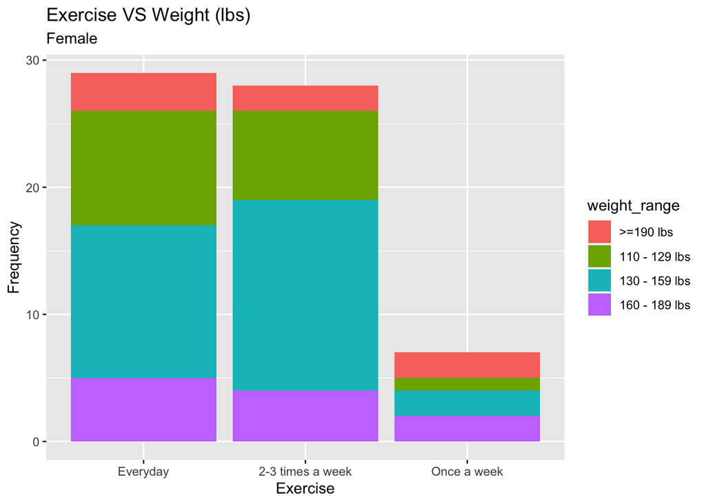

```r
#filter Female:
library(ggplot2)
library(here)
exercise_levels <- c("Everyday", "2-3 times a week","Once a week")
weight_female <- weight_df %>%
  filter(Gender_new == "Female")
ggplot(data=weight_female)+
  geom_bar(mapping= aes(x= factor(exercise_new,exercise_levels), fill=weight_range))+ labs(title="Exercise VS Weight (lbs)", x= "Exercise", y= "Frequency", subtitle= "Female")
```

```r
ggsave(here("Figures","Exercise VS Weight- Female.png"))
```

Male students:

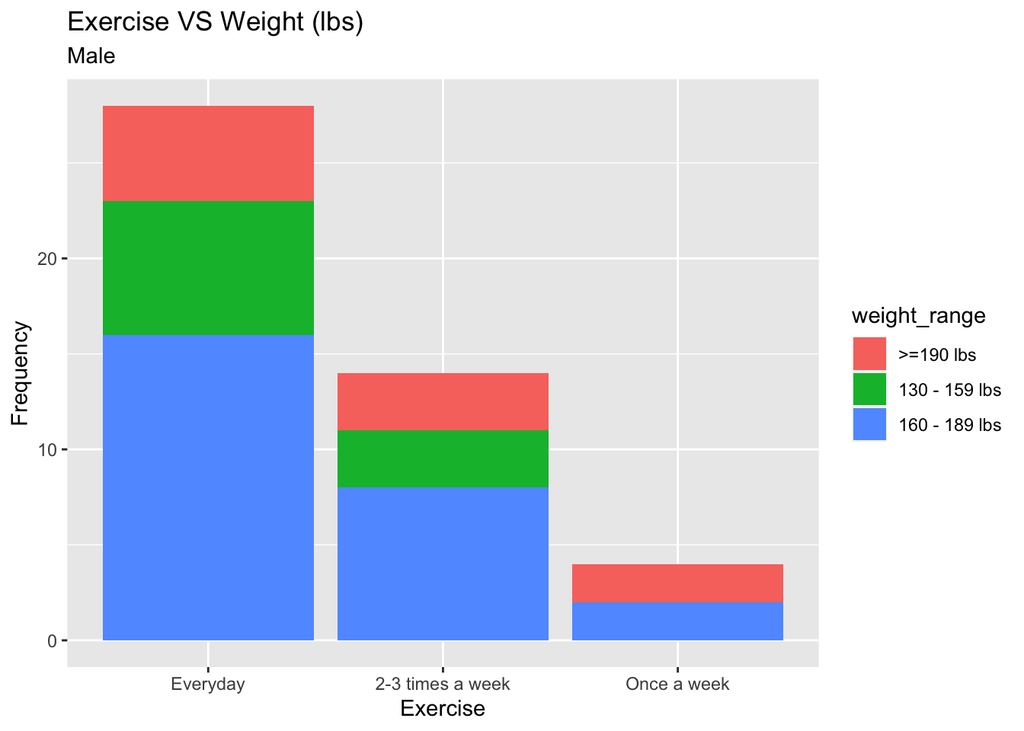

```r
#filter Male:
weight_male <- weight_df %>%
  filter(Gender_new == "Male")
ggplot(data=weight_male)+
  geom_bar(mapping= aes(x=factor(exercise_new,exercise_levels), fill=weight_range))+ labs(title="Exercise VS Weight (lbs)", x= "Exercise", y= "Frequency", subtitle= "Male")
```

```r
ggsave(here("Figures","Exercise VS Weight- Male.png"))
```

#### Question 2: Eating out VS Employment status

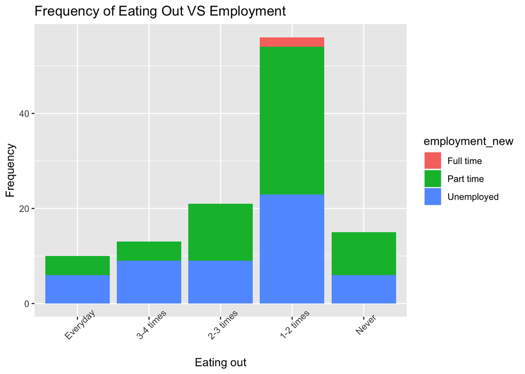

```r
eating_out_levels <- c("Everyday","3-4 times","2-3 times","1-2 times","Never")
ggplot(data=frequency_df)+
  geom_bar(mapping=aes (x=factor(eating_out_new,eating_out_levels), fill=employment_new)) + labs(title = "Frequency of Eating Out VS Employment", x ="Eating out", y="Frequency") + theme(axis.text.x = element_text(angle = 45))
```

```r
ggsave(here("Figures","Eating out VS Employment.png"))
```

#### Question 2: Eating out VS Income

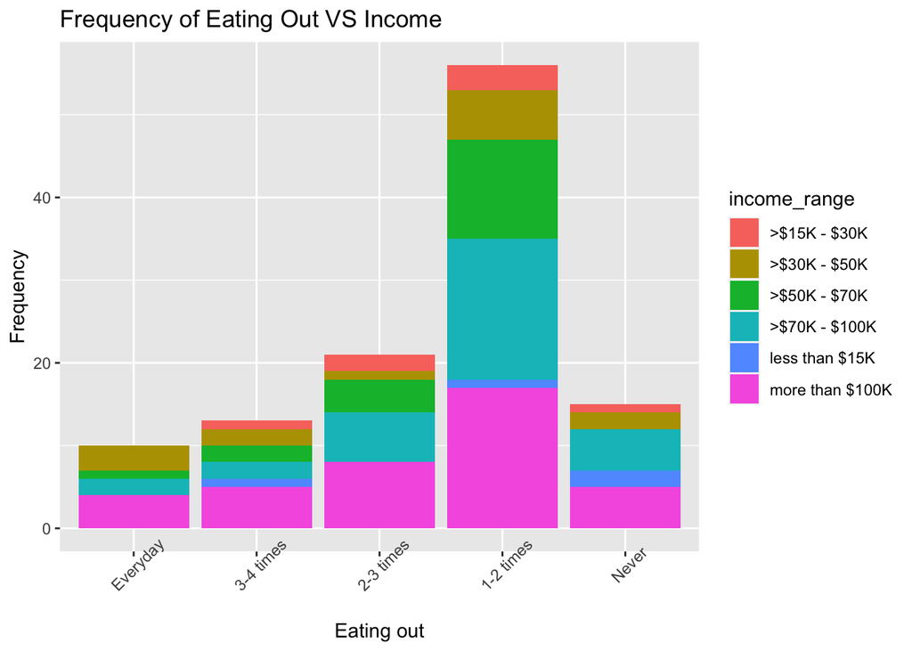

```r
ggplot(data=frequency_df)+
  geom_bar(mapping=aes (x=factor(eating_out_new,eating_out_levels), fill=income_range)) + labs(title = "Frequency of Eating Out VS Income", x ="Eating out", y="Frequency") + theme(axis.text.x = element_text(angle = 45))
```

```r
ggsave(here("Figures","Eating out VS Income.png"))
```

#### Question 2: Eating out VS Living on or off campus

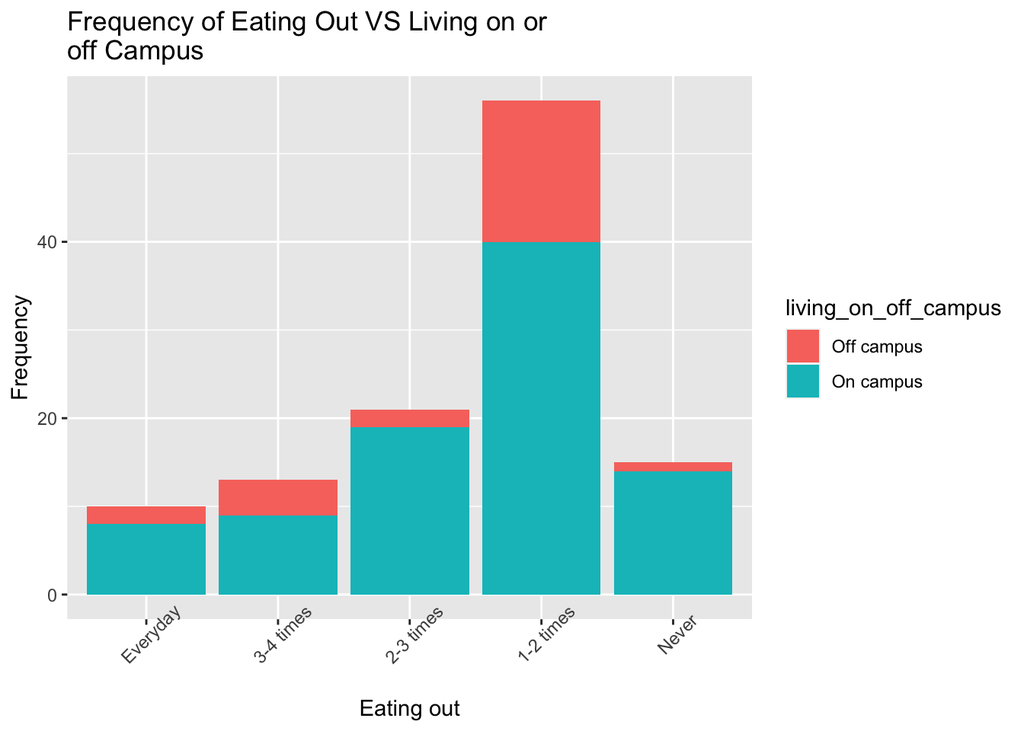

```r
ggplot(data=frequency_df)+
  geom_bar(mapping=aes (x=factor(eating_out_new,eating_out_levels), fill=living_on_off_campus)) + labs(title = "Frequency of Eating Out VS Living on or \noff Campus", x ="Eating out", y="Frequency") + theme(axis.text.x = element_text(angle = 45))
```

```r
ggsave(here("Figures","Eating out VSLiving on or off campus.png"))
```

#### Question 3: Exercise VS Nutritional check

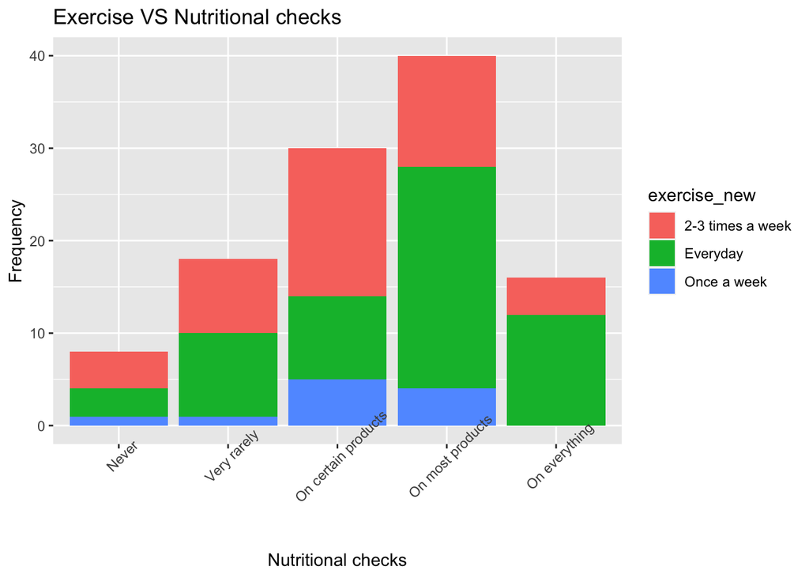

```r
nutri_levels <- c("Never","Very rarely","On certain products", "On most products", "On everything")

ggplot(data=exercise_df)+
  geom_bar(mapping=aes(x= factor(nutritional_check_new, nutri_levels),fill= exercise_new)) + labs(title="Exercise VS Nutritional checks", x= "Nutritional checks", y="Frequency") + theme(axis.text.x = element_text(angle = 45))
```

```r
ggsave(here("Figures","Exercise VS Nutritional checks.png"))
```

#### Question 3: Exercise VS Veggie consumption

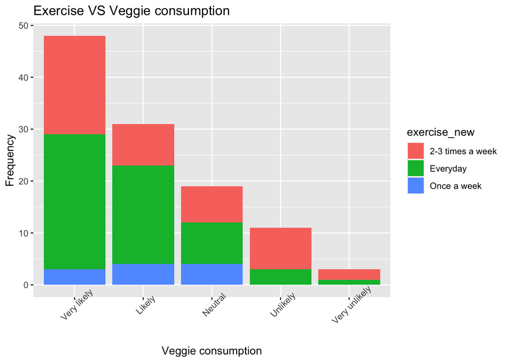

```r
Veggie_consumption_levels <- c("Very likely","Likely","Neutral","Unlikely","Very unlikely")
ggplot(data=exercise_df)+
  geom_bar(mapping=aes(x= factor(veggie_consumption_new,Veggie_consumption_levels),fill=exercise_new)) + labs(title="Exercise VS Veggie consumption", x= "Veggie consumption", y="Frequency") + theme(axis.text.x = element_text(angle = 45))
```

```r
ggsave(here("Figures","Exercise VS Veggie consumption.png"))
```

#### Question 3: Exercise VS Fruit consumption

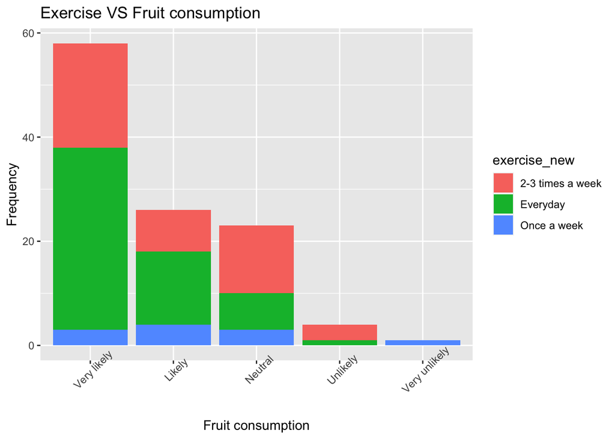

```r
Fruit_consumption_levels <- c("Very likely","Likely","Neutral","Unlikely","Very unlikely")
ggplot(data=exercise_df)+
  geom_bar(mapping=aes(fill=exercise_new,x=factor(fruit_consumption_new,Fruit_consumption_levels))) +
  labs(title="Exercise VS Fruit consumption", x= "Fruit consumption", y="Frequency") + theme(axis.text.x = element_text(angle = 45))
```

```r
ggsave(here("Figures","Exercise VS Fruit consumption.png"))
```

## Basic Statistic test

#### Question 1: Does exercising regularly affects weight of an individual?

```r
weight_female %>%
  select("exercise_new","weight_range") %>%
  table() %>%
  fisher.test()
```

```
##
##  Fisher's Exact Test for Count Data
##
## data:  .
## p-value = 0.6039
## alternative hypothesis: two.sided
```

Since p = 0.7479 which is more than alpha value (0.05), we accept H0 and can conclude that exercise frequency does not affect weight of male college students in our study.

```r
weight_male %>%
  select("exercise_new","weight_range") %>%
  table() %>%
  fisher.test()
```

```
##
##  Fisher's Exact Test for Count Data
##
## data:  .
## p-value = 0.7479
## alternative hypothesis: two.sided
```

#### Question 2: Does factors such as: Employment, Income, and Living on or off campus affect the frequency of eating out for college students?

Test of independence using Fisher’s extract test. alpha value = 0.05 H0: Factor(employment/income/living on or off campus) has no statistical influence to the frequency of college student eating out. Since p = 0.6443 which is more than alpha value (0.05), we accept H0 and can conclude that employment status of a college student does not affect the frequency of eating out.

Employment:

```r
frequency_df %>%
  select("employment_new","eating_out_new") %>%
  table() %>%
  fisher.test()
```

```
##
##  Fisher's Exact Test for Count Data
##
## data:  .
## p-value = 0.6443
## alternative hypothesis: two.sided
```

Income: Since p = 0.6681 which is more than alpha value (0.05), we accept H0 and can conclude that income of a college student does not affect the frequency of eating out.

```r
frequency_df %>%
  select("income_range","eating_out_new") %>%
  table() %>%
  fisher.test(input_table, workspace = 1e7) #increase workspace due to error message
```

```
##
##  Fisher's Exact Test for Count Data
##
## data:  .
## p-value = 0.6681
## alternative hypothesis: two.sided
```

Living on and off campus: Since p = 0.2007 which is more than alpha value (0.05), we accept H0 and can conclude that living on or off campus does not affect the frequency of eating out.

```r
frequency_df %>%
  select("living_on_off_campus","eating_out_new") %>%
  table() %>%
  fisher.test()
```

```
##
##  Fisher's Exact Test for Count Data
##
## data:  .
## p-value = 0.2007
## alternative hypothesis: two.sided
```

#### Question 3: Does students who exercise regularly more likely to make better food choices?

```r
exercise_df %>%
  select("nutritional_check_new","exercise_new") %>%
  table() %>%
  fisher.test()
```

```
##
##  Fisher's Exact Test for Count Data
##
## data:  .
## p-value = 0.1133
## alternative hypothesis: two.sided
```

```r
exercise_df %>%
  select("veggie_consumption_new","exercise_new") %>%
  table() %>%
  fisher.test()
```

```
##
##  Fisher's Exact Test for Count Data
##
## data:  .
## p-value = 0.1485
## alternative hypothesis: two.sided
```

Since p = 0.03453 which is less than alpha value (0.05), we reject H0 and can conclude that students who exercise regularly does consumer more fruits.

```r
exercise_df %>%
  select("fruit_consumption_new","exercise_new") %>%
  table() %>%
  fisher.test()
```

```
##
##  Fisher's Exact Test for Count Data
##
## data:  .
## p-value = 0.03453
## alternative hypothesis: two.sided
```